# rANOMALY use case

Etienne Rifa & Sebastien Theil

17/08/2020

# rANOMALY step-by-step use case.

## Help

Each function have a detailed help accessible in R via `?{funtion}`.

## Tests datasets

The dataset can be downloaded via this [link](https://nextcloud.inrae.fr/s/Zx3iASe64x8oSoM).

This tutorial assume that you have extracted all the read file in a folder named `reads` along with the `sample-metadata.csv` file.

We share a 24 samples test dataset extract from rats feces at two different time (t0 & t50) and in two nutrition conditions. Also included two extraction control sample (blank).

```r
library(DT)
library(ranomaly)
sm <- read.table("sample_metadata.csv", sep="\t",header=TRUE)
DT::datatable(sm)
```

|  | sample.id | temps | type | souche | souche_temps |
| --- | --- | --- | --- | --- | --- |
| 1 | CB-T1 |  | control |  |  |
| 2 | CB-T2 |  | control |  |  |
| 3 | SB1-Sauv0 | t0 | sample | sauvage | sauvage_t0 |
| 4 | SB2-Sauv0 | t0 | sample | sauvage | sauvage_t0 |
| 5 | SB3-Sauv0 | t0 | sample | sauvage | sauvage_t0 |
| 6 | SB4-Sauv0 | t0 | sample | sauvage | sauvage_t0 |
| 7 | SB5-Sauv0 | t0 | sample | sauvage | sauvage_t0 |
| 8 | SB6-Sauv0 | t0 | sample | sauvage | sauvage_t0 |
| 9 | SB7-Mut0 | t0 | sample | mutant | mutant_t0 |
| 10 | SB8-Mut0 | t0 | sample | mutant | mutant_t0 |

[output cut: 16 more lines]

```r
load("decontam_out/robjects.Rdata")
```

## ASV definition with DADA2

The first step will be the creation of ASVs (Amplicon Sequence Variants) thanks to the dada2 package. In rANOMALY, only one function is needed to compute all the different steps require from this package.

Sample names will be extracted from the file name, so files must be formatted as followed : {sample-id1}_R1.fastq.gz {sample-id1}_R2.fastq.gz etc…

```r
dada_res = dada2_fun(path="./reads", dadapool = "pseudo", compress=TRUE, plot=FALSE)
```

Main output: - `read_tracking.csv` that summarize the read number after each filtering step.

```r
DT::datatable(read.table("dada2_out/read_tracking.csv",sep="\t",header=TRUE))
```

|  | X | input | filtered | denoisedF | denoisedR | merged | nonchim |
| --- | --- | --- | --- | --- | --- | --- | --- |
| 1 | CB-T1 | 3387 | 310 | 300 | 296 | 288 | 287 |
| 2 | CB-T2 | 3372 | 280 | 254 | 256 | 235 | 233 |
| 3 | SB1-Sauv0 | 52216 | 33540 | 33417 | 33412 | 33039 | 29381 |
| 4 | SB10-Mut0 | 51616 | 34243 | 34163 | 34095 | 33393 | 25965 |
| 5 | SB11-Mut0 | 55522 | 31251 | 31054 | 31013 | 29780 | 19933 |
| 6 | SB12-Mut0 | 54443 | 34865 | 34774 | 34772 | 34546 | 30496 |
| 7 | SB13-Sauv50 | 43507 | 28385 | 28273 | 28260 | 27669 | 21865 |
| 8 | SB14-Sauv50 | 47370 | 30786 | 30709 | 30721 | 30478 | 29283 |
| 9 | SB15-Sauv50 | 49012 | 31699 | 31553 | 31557 | 30901 | 25303 |
| 10 | SB16-Sauv50 | 48711 | 31503 | 31408 | 31370 | 30935 | 26833 |

[output cut: 16 more lines]

The sample names extracted from the file name. We consider as sample name anything that is before the first underscore. This must match the sample names that are in sample metadata files. *input*: raw read number. *filtered*: after dada2 filtering step: no N’s in sequence, low quality, and phiX. *denoisedF* & *denoisedR*: after denoising. Forward & Reverse. *merged*: after merging R1 & R2. *nonchim*: after chimeras filtering.

- `dada2_robjects.Rdata` with raw ASV table and representative sequences in objects `otu.table`, `seqtab.export` & `seqtab.nochim`.
- `raw_asv-table.csv`
- `rep-seqs.fna`

## Taxonomic assignment

This script uses IDTAXA function from DECIPHER package, and allows to use 2 differents databases. It keeps the best assignation on 2 criteria, resolution (depth) and confidence. The final taxonomy is validated by multiple ancestors taxa and incongruity correction step.

We share the latest databases we use in the IDTAXA format in this link. You can also generate your own database following those instructions and scripts we provide in another repository.

```r
tax.table = assign_taxo_fun(dada_res = dada_res, id_db = c("path_to_your_banks/silva/SILVA_SSU_r132_March2018.RData","path_to_your_banks/DAIRYdb_v1.2.0_20190222_IDTAXA.RData") )
```

Main output: - `taxo_robjects.Rdata` with taxonomy in phyloseq format in `tax.table` object. - `final_tax_table.csv` the final assignation table. - `allDB_tax_table.csv` assignations from the two databases.

## Phylogenetic Tree

The phylogenetic tree from the representative sequences is generated using phangorn and DECIPHER packages.

```r
tree = generate_tree_fun(dada_res)
```

Main output: - `tree_robjects.Rdata` with phylogenetic `tree` object in phyloseq format.

## Phyloseq object

To create a phyloseq object, we need to merge four objects and one file: - the asv table `otu.table` and the representative sequences `seqtab.nochim` from `dada2_robjects.Rdata` - a taxonomy table `taxo_robjects.Rdata` from `taxo_robjects.Rdata` - the phylogenetic tree `tree` from `tree_robjects.Rdata` - metadata from `sample-metadata.csv`

```r
data = generate_phyloseq_fun(dada_res = dada_res, taxtable = tax.table, tree = tree, metadata = "./sample_metadata.csv")
```

Main output: - `robjects.Rdata` with phyloseq object in `data` for raw counts and `data_rel` for relative abundance.

## Decontamination

`decontam.r` scripts uses [decontam](https://www.bioconductor.org/packages/release/bioc/html/decontam.html) R package with control samples to filter contaminants. The decontam package offers two main methods, frequency and prevalence (and then you can combine those methods). For frequency method, it is mandatory to have the dna concentration of each sample in phyloseq (and hence in the `sample-metadata.csv`). “*In this method, the distribution of the frequency of each sequence feature as a function of the input DNA concentration is used to identify contaminants.*” In the prevalence methods no need of DNA quantification. “*In this method, the prevalence (presence/absence across samples) of each sequence feature in true positive samples is compared to the prevalence in negative controls to identify contaminants.*”

Tips: sequencing plateforms often quantify the DNA before sequencing, but do not automaticaly give the information. Just ask for it ;).

Our script integrates the basics ASV frequency (nb_reads_ASV/nb_total_reads) and prevalence (nb_sample_ASV/nb_total_sample) filtering. As in our lab we had a known recurrent contaminant we included an option to filter out ASV based on they taxa names.

```r
data = decontam_fun(data = data, domain = "Bacteria", column = "type", ctrl_identifier = "control", spl_identifier = "sample", number = 100)
```

Main output: - `robjects.Rdata` with contaminant filtered phyloseq object named `data`. - `Exclu_out.csv` list of filtered ASVs for each filtering step. - Kronas before and after filtering. - `raw_asv-table.csv` & `relative_asv-table.csv`. - `venndiag_filtering.png`.

## Plots, diversity and statistics

!!! We are currently developping a ShinyApp to visualize your data, sub-select your samples/taxons and do all those analyses interactively !!! [ExploreMetabar](https://forgemia.inra.fr/umrf/exploremetabar)

### Rarefaction curves and composition

This script generates an html page, with rarefaction curves, composition plots of raw and relative abundances.

```r
bars_fun(data = data, column1 = "temps", column2 = "souche", rank=c("Phylum,Genus"), rare = "souche")
```

```
## INFO [2020-08-17 17:14:56] Plotting bar (Phylum)...
```

```
## Pick the abundance matrix taxa x samples
```

```
## Average the samples by group
```

```
## Sort samples
```

```
## Prepare data.frame.
```

```
## Construct the plots
```

```
## Pick the abundance matrix taxa x samples
```

```
## Average the samples by group
```

```
## Sort samples
```

```
## Prepare data.frame.
```

```
## Construct the plots
```

```
## INFO [2020-08-17 17:14:57] Done.
## INFO [2020-08-17 17:14:57] Plotting bar (Genus)...
```

```
## Pick the abundance matrix taxa x samples
```

```
## Average the samples by group
```

```
## Sort samples
```

```
## Prepare data.frame.
```

```
## Construct the plots
```

```
## Pick the abundance matrix taxa x samples
```

```
## Average the samples by group
```

```
## Sort samples
```

```
## Prepare data.frame.
```

```
## Construct the plots
```

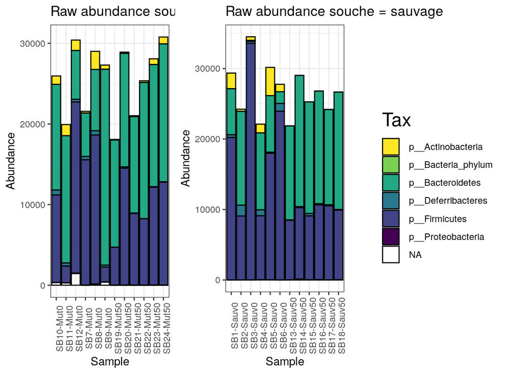

[output not shown]

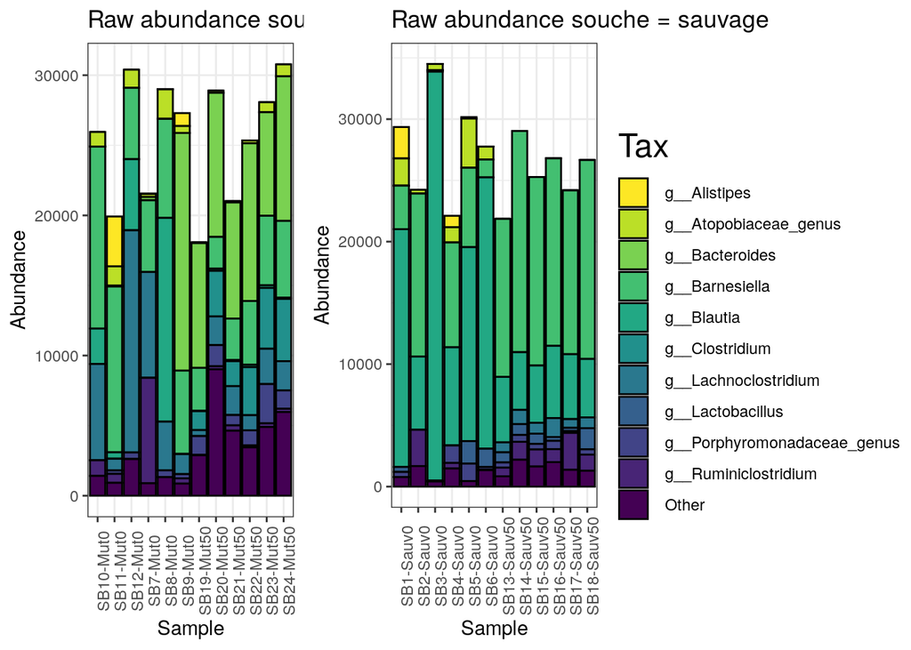

```
## INFO [2020-08-17 17:15:03] Done.
## INFO [2020-08-17 17:15:03] Plotting sample.id composition (Phylum)...
## INFO [2020-08-17 17:15:03] Plotting sample.id composition (Phylum)...
```

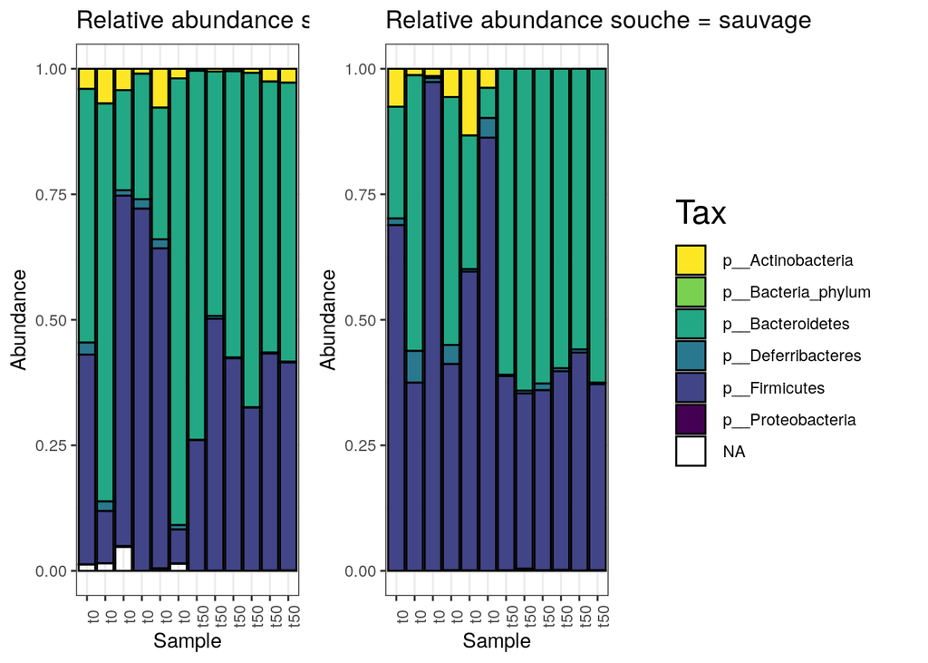

```
## INFO [2020-08-17 17:15:04] Done.
## INFO [2020-08-17 17:15:04] Done.
## INFO [2020-08-17 17:15:04] Plotting sample.id composition (Genus)...
## INFO [2020-08-17 17:15:05] Plotting sample.id composition (Genus)...
```

```
## INFO [2020-08-17 17:15:06] Done.
## INFO [2020-08-17 17:15:06] Done.
```

```
##
##
## processing file: bars2.Rmd
```

[output not shown]

[output cut: 94 more lines]

[output not shown]

```
## output file: bars2.knit.md
```

[output not shown]

```
##
## Output created: plot_bar///bars.html
```

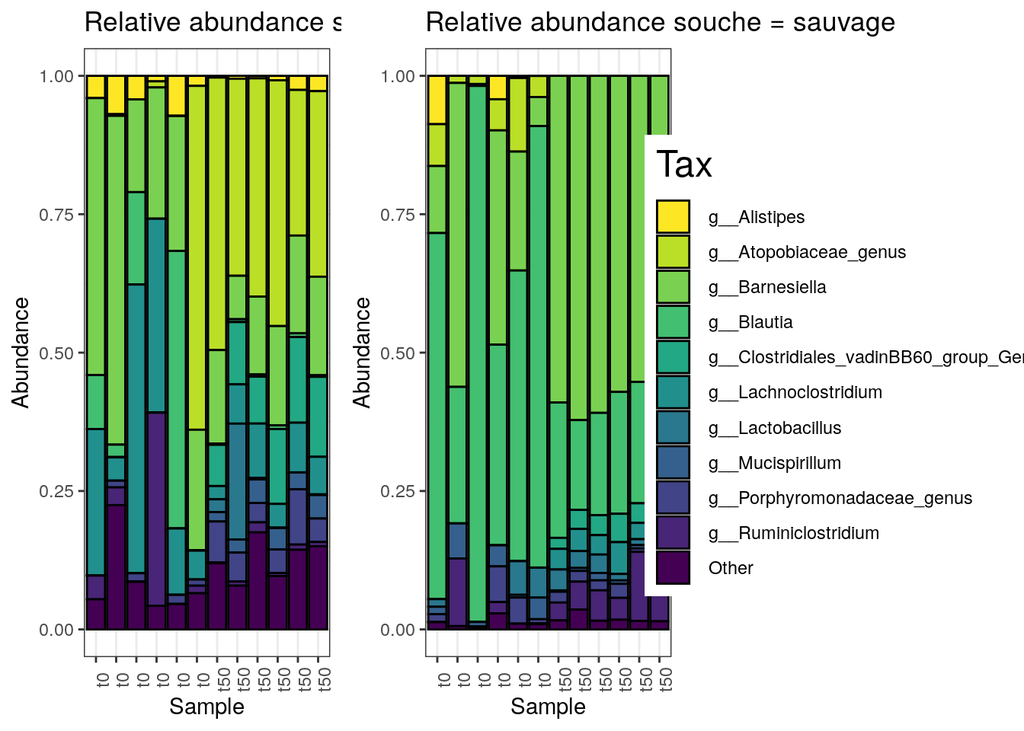

```
## INFO [2020-08-17 17:15:14] Finish.
## INFO [2020-08-17 17:15:14] Return values.
```

[output not shown]